# In Class Assignment Week 2

## Part I:

1. The data set at rnf6080.dat records hourly rainfall at a certain location in Canada, every day from 1960 to 1980. First, we need to load the data set into R using the command read.table(). Use the help function to learn what arguments this function takes. Once you have the necessary input, load the data set into R and make it a data frame called rain.df.

```r
#Load data file
rain.df = as.data.frame(read.table('rnf6080.dat'))
```

2. How many rows and columns does rain.df have? (If there are not 5070 rows and 27 columns, something is wrong; check the previous part to see what might have gone wrong in the previous part.)

```r
#Finds number of rows and columns
nrows = nrow(rain.df)
ncols = ncol(rain.df)
nrows
```

```
## [1] 5070
```

```r
ncols
```

```
## [1] 27
```

3. What are the names of the columns of rain.df?

```r
#Finds names of columns
col_names = names(rain.df)
col_names
```

```
##  [1] "V1"  "V2"  "V3"  "V4"  "V5"  "V6"  "V7"  "V8"  "V9"  "V10" "V11"
## [12] "V12" "V13" "V14" "V15" "V16" "V17" "V18" "V19" "V20" "V21" "V22"
## [23] "V23" "V24" "V25" "V26" "V27"
```

4. What is the value of row 5, column 7 of rain.df?

```r
#Finds value of row 5,7
value_row5_col7 = rain.df[5,7]
value_row5_col7
```

```
## [1] 0
```

5. Display the second row of rain.df in its entirety.

```r
#Prints the second row
print_second_row = rain.df[2,]
print_second_row
```

```
##   V1 V2 V3 V4 V5 V6 V7 V8 V9 V10 V11 V12 V13 V14 V15 V16 V17 V18 V19 V20
## 2 60  4  2  0  0  0  0  0  0   0   0   0   0   0   0   0   0   0   0   0
##   V21 V22 V23 V24 V25 V26 V27
## 2   0   0   0   0   0   0   0
```

6. Explain what the command below doesby running it on your data and examining the object. (You may find the display functions head() and tail() useful here.) Is it clear now what the last 24 columns represent?

```
names(rain.df) <- c("year","month","day",seq(0,23))
```

This command changes the labels of the first three columns to “year”, “month”, and “day” respectively. The last 24 columns represent the hour of the day.

7. Create a new column in the data frame called daily, which is the sum of the rightmost 24 columns. With this column, create a histogram of the values in this column, which are supposed to be daily rainfall values. What is wrong with this picture?

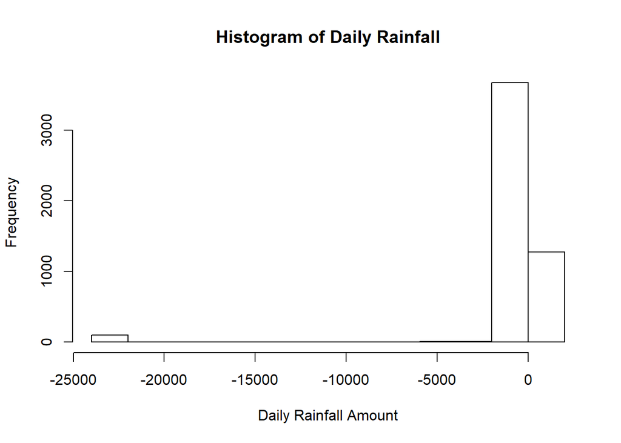

```r
#Adds column
rain.df =
rain.df %>%
  mutate(daily = rowSums(rain.df[, 4:27]))
#histogram of daily rainfall
hist(rain.df$daily, main = "Histogram of Daily Rainfall", xlab = "Daily Rainfall Amount", ylab = "Frequency")
```

This histogram has negative values. There can be no negative rainfall amounts.

8. Create a new data frame rain.df.fixed that takes the original and fixes it for the apparent flaw you have discovered. Having done this, produce a new histogram with the corrected data and explain why this is more reasonable.

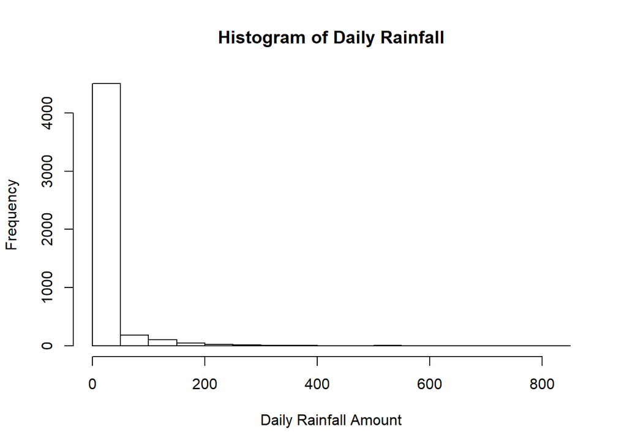

```r
#Changed all values <0 to NA
rain.df[rain.df < 0] = NA
hist(rain.df$daily, main = "Histogram of Daily Rainfall", xlab = "Daily Rainfall Amount", ylab = "Frequency")
```

This graph is much more reasonable because there are no negative values.

## Part II:

### Question 1:

1. Filter all flights on your birthday.

```r
#inspect structure of flights dataset
str(flights)
```

```
## Classes 'tbl_df', 'tbl' and 'data.frame':    336776 obs. of  19 variables:
##  $ year          : int  2013 2013 2013 2013 2013 2013 2013 2013 2013 2013 ...
##  $ month         : int  1 1 1 1 1 1 1 1 1 1 ...
##  $ day           : int  1 1 1 1 1 1 1 1 1 1 ...
##  $ dep_time      : int  517 533 542 544 554 554 555 557 557 558 ...
##  $ sched_dep_time: int  515 529 540 545 600 558 600 600 600 600 ...
##  $ dep_delay     : num  2 4 2 -1 -6 -4 -5 -3 -3 -2 ...
##  $ arr_time      : int  830 850 923 1004 812 740 913 709 838 753 ...
##  $ sched_arr_time: int  819 830 850 1022 837 728 854 723 846 745 ...
##  $ arr_delay     : num  11 20 33 -18 -25 12 19 -14 -8 8 ...
##  $ carrier       : chr  "UA" "UA" "AA" "B6" ...
##  $ flight        : int  1545 1714 1141 725 461 1696 507 5708 79 301 ...
##  $ tailnum       : chr  "N14228" "N24211" "N619AA" "N804JB" ...
##  $ origin        : chr  "EWR" "LGA" "JFK" "JFK" ...
##  $ dest          : chr  "IAH" "IAH" "MIA" "BQN" ...
##  $ air_time      : num  227 227 160 183 116 150 158 53 140 138 ...
##  $ distance      : num  1400 1416 1089 1576 762 ...
##  $ hour          : num  5 5 5 5 6 5 6 6 6 6 ...
##  $ minute        : num  15 29 40 45 0 58 0 0 0 0 ...
##  $ time_hour     : POSIXct, format: "2013-01-01 05:00:00" "2013-01-01 05:00:00" ...
```

```r
#Part 1:
flights %>%
  filter(month == 07 & day == 22)
```

```
## # A tibble: 1,000 x 19
##     year month   day dep_time sched_dep_time dep_delay arr_time
##    <int> <int> <int>    <int>          <int>     <dbl>    <int>
##  1  2013     7    22        1           2305        56      135
##  2  2013     7    22        3           1942       261      129
##  3  2013     7    22        7           2129       158      125
##  4  2013     7    22        7           2245        82      338
##  5  2013     7    22       18           2057       201      255
##  6  2013     7    22       19           2030       229      139
##  7  2013     7    22       22           2359        23      454
##  8  2013     7    22       22           2054       208      311
##  9  2013     7    22       27           2250        97      222
## 10  2013     7    22       27           2231       116      441
## # ... with 990 more rows, and 12 more variables: sched_arr_time <int>,
## #   arr_delay <dbl>, carrier <chr>, flight <int>, tailnum <chr>,
## #   origin <chr>, dest <chr>, air_time <dbl>, distance <dbl>, hour <dbl>,
## #   minute <dbl>, time_hour <dttm>
```

### Question 2:

2. Filter all flights in rows 567 - 589

```r
#Part 2:
flights %>%
  filter(row_number() %in% 567:589)
```

```
## # A tibble: 23 x 19
##     year month   day dep_time sched_dep_time dep_delay arr_time
##    <int> <int> <int>    <int>          <int>     <dbl>    <int>
##  1  2013     1     1     1653           1700        -7     2005
##  2  2013     1     1     1654           1644        10     1752
##  3  2013     1     1     1654           1700        -6     2020
##  4  2013     1     1     1655           1621        34     1804
##  5  2013     1     1     1655           1700        -5     1953
##  6  2013     1     1     1655           1700        -5     2027
##  7  2013     1     1     1655           1655         0     2025
##  8  2013     1     1     1656           1700        -4     1941
##  9  2013     1     1     1657           1650         7     1921
## 10  2013     1     1     1657           1630        27     1948
## # ... with 13 more rows, and 12 more variables: sched_arr_time <int>,
## #   arr_delay <dbl>, carrier <chr>, flight <int>, tailnum <chr>,
## #   origin <chr>, dest <chr>, air_time <dbl>, distance <dbl>, hour <dbl>,
## #   minute <dbl>, time_hour <dttm>
```

### Question 3:

3. Use arrange() to order the data by year, month and day

```r
#Part 3:
flights %>%
  arrange(year, month, day)
```

```
## # A tibble: 336,776 x 19
##     year month   day dep_time sched_dep_time dep_delay arr_time
##    <int> <int> <int>    <int>          <int>     <dbl>    <int>
##  1  2013     1     1      517            515         2      830
##  2  2013     1     1      533            529         4      850
##  3  2013     1     1      542            540         2      923
##  4  2013     1     1      544            545        -1     1004
##  5  2013     1     1      554            600        -6      812
##  6  2013     1     1      554            558        -4      740
##  7  2013     1     1      555            600        -5      913
##  8  2013     1     1      557            600        -3      709
##  9  2013     1     1      557            600        -3      838
## 10  2013     1     1      558            600        -2      753
## # ... with 336,766 more rows, and 12 more variables: sched_arr_time <int>,
## #   arr_delay <dbl>, carrier <chr>, flight <int>, tailnum <chr>,
## #   origin <chr>, dest <chr>, air_time <dbl>, distance <dbl>, hour <dbl>,
## #   minute <dbl>, time_hour <dttm>
```

# Question 4:

4. Use desc() to arrange flights by arrival delay.

```r
#Part 4:
flights %>%
  arrange(desc(arr_delay))
```

```
## # A tibble: 336,776 x 19
##     year month   day dep_time sched_dep_time dep_delay arr_time
##    <int> <int> <int>    <int>          <int>     <dbl>    <int>
##  1  2013     1     9      641            900      1301     1242
##  2  2013     6    15     1432           1935      1137     1607
##  3  2013     1    10     1121           1635      1126     1239
##  4  2013     9    20     1139           1845      1014     1457
##  5  2013     7    22      845           1600      1005     1044
##  6  2013     4    10     1100           1900       960     1342
##  7  2013     3    17     2321            810       911      135
##  8  2013     7    22     2257            759       898      121
##  9  2013    12     5      756           1700       896     1058
## 10  2013     5     3     1133           2055       878     1250
## # ... with 336,766 more rows, and 12 more variables: sched_arr_time <int>,
## #   arr_delay <dbl>, carrier <chr>, flight <int>, tailnum <chr>,
## #   origin <chr>, dest <chr>, air_time <dbl>, distance <dbl>, hour <dbl>,
## #   minute <dbl>, time_hour <dttm>
```

### Question 5:

5. Select columns containing data information.

```r
#Part 5:
flights %>%
  select(1:3)
```

```
## # A tibble: 336,776 x 3
##     year month   day
##    <int> <int> <int>
##  1  2013     1     1
##  2  2013     1     1
##  3  2013     1     1
##  4  2013     1     1
##  5  2013     1     1
##  6  2013     1     1
##  7  2013     1     1
##  8  2013     1     1
##  9  2013     1     1
## 10  2013     1     1
## # ... with 336,766 more rows
```

### QUestion 6:

6. Select columns including only plane information.

```r
#Part 6:
flights %>%
  select(flight, tailnum, carrier)
```

```
## # A tibble: 336,776 x 3
##    flight tailnum carrier
##     <int> <chr>   <chr>
##  1   1545 N14228  UA
##  2   1714 N24211  UA
##  3   1141 N619AA  AA
##  4    725 N804JB  B6
##  5    461 N668DN  DL
##  6   1696 N39463  UA
##  7    507 N516JB  B6
##  8   5708 N829AS  EV
##  9     79 N593JB  B6
## 10    301 N3ALAA  AA
## # ... with 336,766 more rows
```

### Question 7:

7. Rename tailnum to tail_num

```r
#Part 7:
flights %>%
  rename('tail_num' = tailnum)
```

```
## # A tibble: 336,776 x 19
##     year month   day dep_time sched_dep_time dep_delay arr_time
##    <int> <int> <int>    <int>          <int>     <dbl>    <int>
##  1  2013     1     1      517            515         2      830
##  2  2013     1     1      533            529         4      850
##  3  2013     1     1      542            540         2      923
##  4  2013     1     1      544            545        -1     1004
##  5  2013     1     1      554            600        -6      812
##  6  2013     1     1      554            558        -4      740
##  7  2013     1     1      555            600        -5      913
##  8  2013     1     1      557            600        -3      709
##  9  2013     1     1      557            600        -3      838
## 10  2013     1     1      558            600        -2      753
## # ... with 336,766 more rows, and 12 more variables: sched_arr_time <int>,
## #   arr_delay <dbl>, carrier <chr>, flight <int>, tail_num <chr>,
## #   origin <chr>, dest <chr>, air_time <dbl>, distance <dbl>, hour <dbl>,
## #   minute <dbl>, time_hour <dttm>
```

### Question 8:

8. Create a variable called gain which describes the difference between arrival delap and departure delay.

```r
#Part 8: Calculates the total time delayed or gained.
flights %>%
  mutate(gain = arr_delay + dep_delay)
```

```
## # A tibble: 336,776 x 20
##     year month   day dep_time sched_dep_time dep_delay arr_time
##    <int> <int> <int>    <int>          <int>     <dbl>    <int>
##  1  2013     1     1      517            515         2      830
##  2  2013     1     1      533            529         4      850
##  3  2013     1     1      542            540         2      923
##  4  2013     1     1      544            545        -1     1004
##  5  2013     1     1      554            600        -6      812
##  6  2013     1     1      554            558        -4      740
##  7  2013     1     1      555            600        -5      913
##  8  2013     1     1      557            600        -3      709
##  9  2013     1     1      557            600        -3      838
## 10  2013     1     1      558            600        -2      753
## # ... with 336,766 more rows, and 13 more variables: sched_arr_time <int>,
## #   arr_delay <dbl>, carrier <chr>, flight <int>, tailnum <chr>,
## #   origin <chr>, dest <chr>, air_time <dbl>, distance <dbl>, hour <dbl>,
## #   minute <dbl>, time_hour <dttm>, gain <dbl>
```

### Question 9:

9. Create a variable called speed which is distance over time in hours.

```r
#Part 9:
flights %>%
  mutate(speed = distance/(air_time/60))
```

```
## # A tibble: 336,776 x 20
##     year month   day dep_time sched_dep_time dep_delay arr_time
##    <int> <int> <int>    <int>          <int>     <dbl>    <int>
##  1  2013     1     1      517            515         2      830
##  2  2013     1     1      533            529         4      850
##  3  2013     1     1      542            540         2      923
##  4  2013     1     1      544            545        -1     1004
##  5  2013     1     1      554            600        -6      812
##  6  2013     1     1      554            558        -4      740
##  7  2013     1     1      555            600        -5      913
##  8  2013     1     1      557            600        -3      709
##  9  2013     1     1      557            600        -3      838
## 10  2013     1     1      558            600        -2      753
## # ... with 336,766 more rows, and 13 more variables: sched_arr_time <int>,
## #   arr_delay <dbl>, carrier <chr>, flight <int>, tailnum <chr>,
## #   origin <chr>, dest <chr>, air_time <dbl>, distance <dbl>, hour <dbl>,
## #   minute <dbl>, time_hour <dttm>, speed <dbl>
```

### Question 10:

10. Summarise the average delay for all flights.

```r
#Part 10:
flights %>%
  summarise(mean(arr_delay + dep_delay, na.rm = TRUE))
```

```
## # A tibble: 1 x 1
##   `mean(arr_delay + dep_delay, na.rm = TRUE)`
##                                         <dbl>
## 1                                        19.5
```

## Overall Questions:

### Question 11:

11. Split the complete dataset into individual planes and then summarise each plane by counting the number of flights (count = n()) and computing the average distance and arrival delay . Then plot this:

```
ggplot(delay, aes(dist, delay)) +
  geom_point(aes(size = count), alpha = 1/2) +
  geom_smooth() +
  scale_size_area()
```

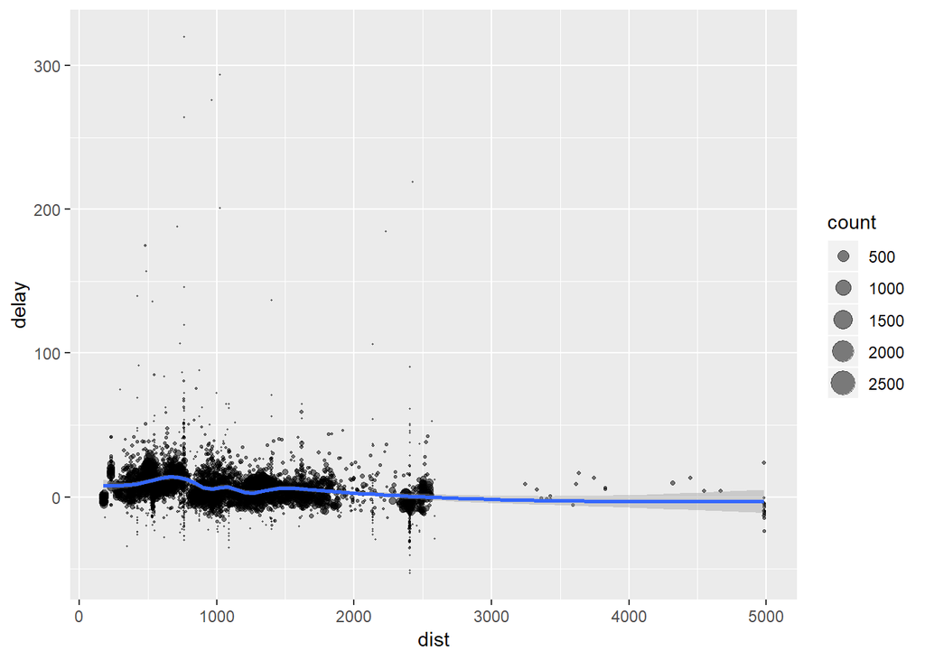

```r
delay =
  flights %>%
  group_by(tailnum) %>%
  summarise(count = n(), dist = mean(distance, na.rm = TRUE), delay = mean(arr_delay, na.rm = TRUE))

ggplot(delay, aes(dist, delay)) +
  geom_point(aes(size = count), alpha = 1/2) +
  geom_smooth() +
  scale_size_area()
```

### Question 12:

12. Find the number of planes and the number of flights that go to each possible destination.

```r
#Part 12:
flights %>%
  group_by(dest) %>%
  summarise(num_flights = n(), num_planes = n_distinct(tailnum))
```

```
## # A tibble: 105 x 3
##    dest  num_flights num_planes
##    <chr>       <int>      <int>
##  1 ABQ           254        108
##  2 ACK           265         58
##  3 ALB           439        172
##  4 ANC             8          6
##  5 ATL         17215       1180
##  6 AUS          2439        993
##  7 AVL           275        159
##  8 BDL           443        186
##  9 BGR           375         46
## 10 BHM           297         45
## # ... with 95 more rows
```

### Question 13:

Consider the code Below:

```r
filter(
  summarise(
    select(
      group_by(flights, year, month, day),
      arr_delay, dep_delay
    ),
    arr = mean(arr_delay, na.rm = TRUE),
    dep = mean(dep_delay, na.rm = TRUE)
  ),
  arr > 30 | dep > 30
)
```

```
## # A tibble: 49 x 5
## # Groups:   year, month [11]
##     year month   day   arr   dep
##    <int> <int> <int> <dbl> <dbl>
##  1  2013     1    16  34.2  24.6
##  2  2013     1    31  32.6  28.7
##  3  2013     2    11  36.3  39.1
##  4  2013     2    27  31.3  37.8
##  5  2013     3     8  85.9  83.5
##  6  2013     3    18  41.3  30.1
##  7  2013     4    10  38.4  33.0
##  8  2013     4    12  36.0  34.8
##  9  2013     4    18  36.0  34.9
## 10  2013     4    19  47.9  46.1
## # ... with 39 more rows
```

1. What are some problems with this function?
2. How easy is it to follow the logic of this?
3. Rewrite this using piping to make it more understandable.
4. Does your rewritten command give the same results?

#### Part a:

The problem with this function is that it serves several purposes. The independent functions should be separated for absolute clarity.

#### Part b:

Because this one large function does multiple things, the clarity/logic behind it isn’t crystal clear.

#### Part c:

```r
flights %>%
  group_by(year, month, day) %>%
  select(arr_delay, dep_delay) %>%
  summarise(arr = mean(arr_delay, na.rm = TRUE),
            dep = mean(dep_delay, na.rm = TRUE)) %>%
  filter(arr > 30 | dep > 30)
```

```
## # A tibble: 49 x 5
## # Groups:   year, month [11]
##     year month   day   arr   dep
##    <int> <int> <int> <dbl> <dbl>
##  1  2013     1    16  34.2  24.6
##  2  2013     1    31  32.6  28.7
##  3  2013     2    11  36.3  39.1
##  4  2013     2    27  31.3  37.8
##  5  2013     3     8  85.9  83.5
##  6  2013     3    18  41.3  30.1
##  7  2013     4    10  38.4  33.0
##  8  2013     4    12  36.0  34.8
##  9  2013     4    18  36.0  34.9
## 10  2013     4    19  47.9  46.1
## # ... with 39 more rows
```

### Part d:

Yes, it gives the same results.

### Question 14:

Consider the code below:

```
hourly_delay <- filter(
  summarise(
    group_by(
      filter(
        flights,
        !is.na(dep_delay)
      ),
      date, hour
    ),
    delay=mean(dep_delay),
    n=n()
  ),
  n>10
)
```

1. What are some problems with this function?
2. How easy is it to follow the logic of this?
3. Rewrite this using piping to make it more understandable.
4. Does your rewritten command give the same results?

#### Part a:

This doesn’t even run because there is no “date” variable. It is extremely chaotic and I hate the arrow instead of equal sign. They need to at least write the arguments of filter on the same line.

#### Part b:

It is very hard to follow the logic.

#### Part c:

```r
hourly_delay =
  flights %>%
    unite("date", 1:3, sep = "-" ) %>%
    filter(!is.na(dep_delay)) %>%
    group_by(date, hour) %>%
    summarise(delay = mean(dep_delay), n = n()) %>%
    filter(n > 10)%>%
    arrange(date, hour)
```

#### Part d:

There weren’t results from the previous version so it is impossible to compare. However, if there were an explicit date variable, I think they would give the same results.

## Creative Exploration Part: